# Agrupamiento Jerárquico aglomerativo para un Dataset de enfermedades cardiacas

Andreu Cantó y Amparo Gálvez

Disponemos de una base de datos llamada **'data_patiens.csv'** que se compone de datos de más de 300 pacientes. Cada dato es una 14 tupla de características describiendo aspectos de la enfermedad cardiaca.

Vamos a utilizar el agrupamiento jerárquico aglomerativo para ver si alguna de las combinaciones 'Linkage y métrica' nos acerca a la verdadera clasificación de los datos, que está indicada en la última fila del dataset (etiquetada como 'Target').

### Paso 1. Preprocesamiento del dataset

Hay que tomar como costumbre que antes de realizar un agrupamiento hay que pre-procesar el dataset mirando los siguientes aspectos: -Tratar el problema de los datos incompletos (eliminarlos es lo más sencillo). En esta base de datos, las características no válidas están etiquetadas con el valor 'NaN' -Ver el rango de valores de las características para ver si están normalizados, sino, normalizar el dataset (por características en este caso) -Ver si el dataset está equilibrado (Como generalmente no se conoce el ground truth, no se puede saber a priori los datos de cada clase.Pero si podemos ver cómo se ditribuyen los datos de cada característica (gaussiana, poisson, uniforme,...) -Generar un dataset con tuplas reales. Es decir, solucionar el problema de las variables categóricas si existen

```python
#Importación de las librerías de interés
import numpy as np                # linear algebra
import pandas as pd               # data frames
import seaborn as sns             # visualizations
import matplotlib.pyplot as plt   # visualizations
import scipy.stats                # statistics

from scipy.spatial.distance import pdist

from scipy.cluster.hierarchy import dendrogram, linkage, cophenet
from scipy.cluster.hierarchy import complete, fcluster #Cluster Jerarquico Completo

from sklearn import preprocessing

from collections import Counter

import os
```

```python
#Se carga la base de datos usando pandas a trabajar y se ven sus caracteristicas
df = pd.read_csv("./data_patients.csv")

# Print the head of df
print(df.head())
# Print the info of df
print(df.info())
# Print the shape of df
print(df.shape)
```

```
    Age  Sex   Cp  Trestbps   Chol  Fbs  Restecg  Thalach  Exang  Oldpeak  \
0  63.0  1.0  1.0     145.0  233.0  1.0      2.0    150.0    0.0      2.3
1  67.0  1.0  4.0     160.0  286.0  0.0      2.0    108.0    1.0      1.5
2  67.0  1.0  4.0     120.0  229.0  0.0      2.0    129.0    1.0      2.6
3  37.0  1.0  3.0     130.0  250.0  0.0      0.0    187.0    0.0      3.5
4  41.0  0.0  2.0     130.0  204.0  0.0      2.0    172.0    0.0      1.4

   Slope   Ca  Thal  Target
0    3.0  0.0   6.0       2
1    2.0  3.0   3.0       2
2    2.0  2.0   7.0       2
3    3.0  0.0   3.0       3
4    1.0  0.0   3.0       5
<class 'pandas.core.frame.DataFrame'>
RangeIndex: 304 entries, 0 to 303
Data columns (total 14 columns):
 #   Column    Non-Null Count  Dtype
---  ------    --------------  -----
 0   Age       304 non-null    float64
 1   Sex       304 non-null    float64
 2   Cp        304 non-null    float64
 3   Trestbps  304 non-null    float64
 4   Chol      304 non-null    float64
 5   Fbs       304 non-null    float64
 6   Restecg   304 non-null    float64
 7   Thalach   304 non-null    float64
 8   Exang     304 non-null    float64
 9   Oldpeak   304 non-null    float64
 10  Slope     304 non-null    float64
 11  Ca        299 non-null    float64
 12  Thal      302 non-null    float64
 13  Target    304 non-null    int64
dtypes: float64(13), int64(1)
memory usage: 33.4 KB
None
(304, 14)
```

```python
#Vamos a ver si hay valores nulos. Combina los metodos isnull() y sum()
df.isnull().sum()
```

```
Age         0
Sex         0
Cp          0
Trestbps    0
Chol        0
Fbs         0
Restecg     0
Thalach     0
Exang       0
Oldpeak     0
Slope       0
Ca          5
Thal        2
Target      0
dtype: int64
```

```python
#Eliminamos los datos incompletos. Realiza la elimincion sobre el propio df (inplace=True)
df.dropna(inplace = True)
# Print the shape of df
print(df.shape)
```

```
(297, 14)
```

```python
#Guardamos 'Target' en 'solution' y la quitamos (ground truth)
solution = df['Target']
df=df.drop(columns=['Target'])
print("------------")


#A ver cómo es la base de datos
df.describe()
```

|  | Age | Sex | Cp | Trestbps | Chol | Fbs | Restecg | Thalach | Exang | Oldpeak | Slope | Ca | Thal |
| --- | --- | --- | --- | --- | --- | --- | --- | --- | --- | --- | --- | --- | --- |
| count | 297.000000 | 297.000000 | 297.000000 | 297.000000 | 297.000000 | 297.000000 | 297.000000 | 297.000000 | 297.000000 | 297.000000 | 297.000000 | 297.000000 | 297.000000 |
| mean | 54.542088 | 0.676768 | 3.158249 | 131.693603 | 247.350168 | 0.144781 | 0.996633 | 149.599327 | 0.326599 | 1.055556 | 1.602694 | 0.676768 | 4.730640 |
| std | 9.049736 | 0.468500 | 0.964859 | 17.762806 | 51.997583 | 0.352474 | 0.994914 | 22.941562 | 0.469761 | 1.166123 | 0.618187 | 0.938965 | 1.938629 |
| min | 29.000000 | 0.000000 | 1.000000 | 94.000000 | 126.000000 | 0.000000 | 0.000000 | 71.000000 | 0.000000 | 0.000000 | 1.000000 | 0.000000 | 3.000000 |
| 25% | 48.000000 | 0.000000 | 3.000000 | 120.000000 | 211.000000 | 0.000000 | 0.000000 | 133.000000 | 0.000000 | 0.000000 | 1.000000 | 0.000000 | 3.000000 |
| 50% | 56.000000 | 1.000000 | 3.000000 | 130.000000 | 243.000000 | 0.000000 | 1.000000 | 153.000000 | 0.000000 | 0.800000 | 2.000000 | 0.000000 | 3.000000 |
| 75% | 61.000000 | 1.000000 | 4.000000 | 140.000000 | 276.000000 | 0.000000 | 2.000000 | 166.000000 | 1.000000 | 1.600000 | 2.000000 | 1.000000 | 7.000000 |
| max | 77.000000 | 1.000000 | 4.000000 | 200.000000 | 564.000000 | 1.000000 | 2.000000 | 202.000000 | 1.000000 | 6.200000 | 3.000000 | 3.000000 | 7.000000 |

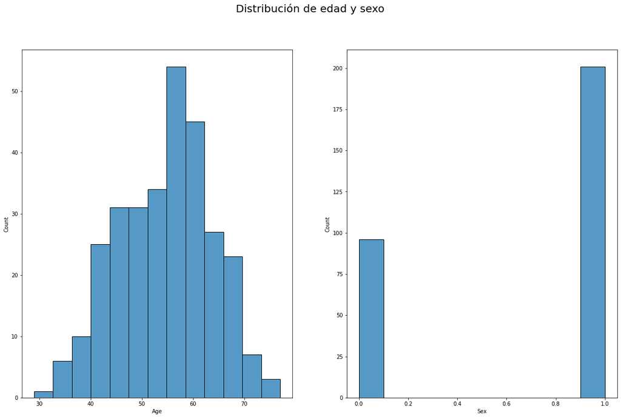

```python
#miramos si está equilibrada en la característica de hombres y mujeres
#y las edades menores de 50 y mayores de 50 (que son fronteras para el problema cardio)
#hacemos histogramas

f, axes = plt.subplots(1,2, figsize=(20, 12))
f.suptitle("Distribución de edad y sexo", fontsize=20)
sns.histplot(df['Age'], ax=axes[0])
sns.histplot(df['Sex'], ax=axes[1])
```

Como habrás observado hay variables categóricas que debemos transformar a numérico si queremos que formen parte de los datos En lugar de usar directamente On Hot Encoding vamos a usar un equivalente. Consulta en pandas el método 'get_dummies' y úsalo con la opción 'drop_first=True' sobre las características "Sex","Cp","Fbs","Restecg","Exang","Slope","Ca","Thal"

**ACTIVIDAD 1** Explica el problema de la multicolinealidad o del 'Dummy variable Trap' consultando 'https://www.learndatasci.com/glossary/dummy-variable-trap/' Explica entonces qué hace este argumento 'drop_first=True'

El principal problema que surge al codificar las características con One Hot Encoding es que se generan variables ficticias de las cuales una puede ser predicha por el resto, esto puede provocar resultados erróneos y poco fiables, por lo que es aconsejable usar drop_first = True para eliminar dicha variable predecible con 'drop_first=True'.

```python
#Codificamos las caracteristicas categoricas contando con la multicolineadlidad

df_dum = pd.get_dummies(data = df, columns = ["Sex","Cp","Fbs","Restecg","Exang","Slope","Ca","Thal"], drop_first = True).astype(int)
```

```python
#Observamos que se han generado más características por el 'One Hot Encoding'
df_dum.describe()
```

|  | Age | Trestbps | Chol | Thalach | Oldpeak | Sex_1.0 | Cp_2.0 | Cp_3.0 | Cp_4.0 | Fbs_1.0 | Restecg_1.0 | Restecg_2.0 | Exang_1.0 | Slope_2.0 | Slope_3.0 | Ca_1.0 | Ca_2.0 | Ca_3.0 | Thal_6.0 | Thal_7.0 |
| --- | --- | --- | --- | --- | --- | --- | --- | --- | --- | --- | --- | --- | --- | --- | --- | --- | --- | --- | --- | --- |
| count | 297.000000 | 297.000000 | 297.000000 | 297.000000 | 297.000000 | 297.000000 | 297.000000 | 297.000000 | 297.000000 | 297.000000 | 297.000000 | 297.000000 | 297.000000 | 297.000000 | 297.000000 | 297.000000 | 297.000000 | 297.000000 | 297.000000 | 297.000000 |
| mean | 54.542088 | 131.693603 | 247.350168 | 149.599327 | 0.777778 | 0.676768 | 0.164983 | 0.279461 | 0.478114 | 0.144781 | 0.013468 | 0.491582 | 0.326599 | 0.461279 | 0.070707 | 0.218855 | 0.127946 | 0.067340 | 0.060606 | 0.387205 |
| std | 9.049736 | 17.762806 | 51.997583 | 22.941562 | 1.076991 | 0.468500 | 0.371792 | 0.449492 | 0.500364 | 0.352474 | 0.115462 | 0.500773 | 0.469761 | 0.499340 | 0.256768 | 0.414168 | 0.334594 | 0.251033 | 0.239009 | 0.487933 |
| min | 29.000000 | 94.000000 | 126.000000 | 71.000000 | 0.000000 | 0.000000 | 0.000000 | 0.000000 | 0.000000 | 0.000000 | 0.000000 | 0.000000 | 0.000000 | 0.000000 | 0.000000 | 0.000000 | 0.000000 | 0.000000 | 0.000000 | 0.000000 |
| 25% | 48.000000 | 120.000000 | 211.000000 | 133.000000 | 0.000000 | 0.000000 | 0.000000 | 0.000000 | 0.000000 | 0.000000 | 0.000000 | 0.000000 | 0.000000 | 0.000000 | 0.000000 | 0.000000 | 0.000000 | 0.000000 | 0.000000 | 0.000000 |
| 50% | 56.000000 | 130.000000 | 243.000000 | 153.000000 | 0.000000 | 1.000000 | 0.000000 | 0.000000 | 0.000000 | 0.000000 | 0.000000 | 0.000000 | 0.000000 | 0.000000 | 0.000000 | 0.000000 | 0.000000 | 0.000000 | 0.000000 | 0.000000 |
| 75% | 61.000000 | 140.000000 | 276.000000 | 166.000000 | 1.000000 | 1.000000 | 0.000000 | 1.000000 | 1.000000 | 0.000000 | 0.000000 | 1.000000 | 1.000000 | 1.000000 | 0.000000 | 0.000000 | 0.000000 | 0.000000 | 0.000000 | 1.000000 |
| max | 77.000000 | 200.000000 | 564.000000 | 202.000000 | 6.000000 | 1.000000 | 1.000000 | 1.000000 | 1.000000 | 1.000000 | 1.000000 | 1.000000 | 1.000000 | 1.000000 | 1.000000 | 1.000000 | 1.000000 | 1.000000 | 1.000000 | 1.000000 |

Estandarización de los datos (cualquier forma de normalización dará resultados parecidos). Usa el método StandardScaler() de preprocessing

```python
heart_scale = df_dum
scaler = preprocessing.StandardScaler()
columns =df_dum.columns
heart_scale[columns] = scaler.fit_transform(heart_scale[columns])
heart_scale.head()
```

|  | Age | Trestbps | Chol | Thalach | Oldpeak | Sex_1.0 | Cp_2.0 | Cp_3.0 | Cp_4.0 | Fbs_1.0 | Restecg_1.0 | Restecg_2.0 | Exang_1.0 | Slope_2.0 | Slope_3.0 | Ca_1.0 | Ca_2.0 | Ca_3.0 | Thal_6.0 | Thal_7.0 |
| --- | --- | --- | --- | --- | --- | --- | --- | --- | --- | --- | --- | --- | --- | --- | --- | --- | --- | --- | --- | --- |
| 0 | 0.936181 | 0.750380 | -0.276443 | 0.017494 | 1.136764 | 0.691095 | -0.444500 | -0.622776 | -0.957146 | 2.430427 | -0.116841 | 1.016979 | -0.696419 | -0.925338 | 3.625308 | -0.529313 | -0.383038 | -0.268705 | 3.937004 | -0.794901 |
| 1 | 1.378929 | 1.596266 | 0.744555 | -1.816334 | 0.206684 | 0.691095 | -0.444500 | -0.622776 | 1.044772 | -0.411450 | -0.116841 | 1.016979 | 1.435916 | 1.080686 | -0.275839 | -0.529313 | -0.383038 | 3.721559 | -0.254000 | -0.794901 |
| 2 | 1.378929 | -0.659431 | -0.353500 | -0.899420 | 1.136764 | 0.691095 | -0.444500 | -0.622776 | 1.044772 | -0.411450 | -0.116841 | 1.016979 | 1.435916 | 1.080686 | -0.275839 | -0.529313 | 2.610707 | -0.268705 | -0.254000 | 1.258018 |
| 3 | -1.941680 | -0.095506 | 0.051047 | 1.633010 | 2.066844 | 0.691095 | -0.444500 | 1.605713 | -0.957146 | -0.411450 | -0.116841 | -0.983304 | -0.696419 | -0.925338 | 3.625308 | -0.529313 | -0.383038 | -0.268705 | -0.254000 | -0.794901 |
| 4 | -1.498933 | -0.095506 | -0.835103 | 0.978071 | 0.206684 | -1.446980 | 2.249717 | -0.622776 | -0.957146 | -0.411450 | -0.116841 | 1.016979 | -0.696419 | -0.925338 | -0.275839 | -0.529313 | -0.383038 | -0.268705 | -0.254000 | -0.794901 |

### Paso 2: Agrupamiento Jerárquico

Vamos repetir este paso 2 para diferentes linkages y métricas. Hay una combinación que debe clavar (si ajustas bien el corte) la solución proporcionada. Repite este paso dos para, al menos, las siguientes combinaciones: Linkage métrica

Average euclidean Average cosine complete euclidean complete cosine ward euclidean median euclidean

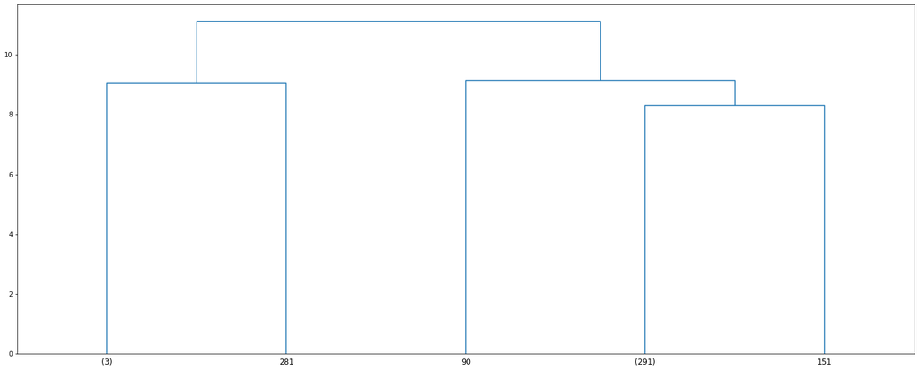

```python
#Primero generamos un dendograma y generamos la matriz de distancias "Z" que se requiere para
#el cluster jerarquico completo

#Realiza el agrupamiento (ver el metodolinkage) especificando los argumentos method, metric, optimal_ordering=True
#Como resultado obtienes la matriz de distancias de fusion
Z = linkage(heart_scale, method='average', metric='euclidean', optimal_ordering=True)
fig = plt.figure(figsize=(25, 10))

#Llama ahora a la confeccion del dendrograma.Usa p=5 y truncate_mode='lastp'
dn = dendrogram(Z, p=5, truncate_mode='lastp')
plt.show()
```

**ACTIVIDAD 2** Explica qué significa el argumento truncate_mode='lastp'

El valor 'lastp' de truncate_mode significa que se mostrarán solo las últimas p fusiones, donde p es un valor entero que se especifica con el argumento p.

Vamos ahora a sacar un agrupamiento de los datos para 5 grupos. Como sabes, el agrup. jerarquico no tiene como parámetro el número de clusters ya que genera desde 1 hasta N. Para sacar la solución para 5 clusters hay que cortar el dendrograma por la línea horizontl que corresponda a estos 5 clusters. Elcorte se realiza con el método 'fcluster()'

**Atencion paso delicado!!** Hay que elegir la distancia de corte 'distan' mirando el dendrograma y eleigiendo el valor de corte más alto (más cercade la raiz) para el número de grupos que queremosde otro modo, no saldrán el número de clusters requerido se puede ir probando hasta que salgan los 5 clusters

```python
#Atencion paso delicado!!
distan = 8
labels = fcluster(Z, t = distan, criterion = 'distance')

#Imprimimos ahora el vector de nuestras soluciones y el groud truth
print(labels)
print("---")
sol = np.array(solution)

print(sol)
```

```
[3 3 3 3 3 3 3 3 3 3 3 3 3 3 3 3 3 3 3 3 3 3 3 3 3 3 3 3 3 3 3 3 3 3 3 3 3
 3 3 3 3 3 3 3 3 3 3 3 3 3 3 3 3 3 3 3 3 3 3 3 3 3 3 3 3 3 3 3 3 3 3 3 3 3
 3 3 3 3 3 3 3 3 3 3 3 3 3 3 3 3 5 3 3 3 3 3 3 3 3 3 3 3 3 3 3 3 3 3 3 3 3
 3 3 3 3 3 3 3 3 3 3 3 3 3 3 3 3 3 3 3 3 3 3 3 3 3 3 3 3 3 3 3 3 3 3 3 3 3
 3 3 3 4 3 3 3 3 3 3 3 3 3 3 3 3 3 3 3 3 3 3 3 3 3 3 3 3 3 3 3 3 3 3 3 3 3
 3 3 3 3 3 3 3 3 3 3 3 3 3 3 3 3 3 3 3 3 3 3 3 3 3 3 3 3 3 3 3 3 3 3 3 3 3
 3 3 3 3 3 3 1 3 3 3 3 3 3 3 3 3 3 3 3 3 3 3 3 3 3 3 3 3 3 3 3 3 1 3 3 3 3
 3 3 3 3 3 3 3 3 3 3 3 3 3 3 3 3 3 3 3 1 3 3 2 3 3 3 3 3 3 3 3 3 3 3 3 3 3
 3]
---
[2 2 2 3 5 5 3 1 4 3 2 5 2 5 3 3 3 2 5 5 2 3 5 2 2 5 5 3 2 2 2 3 5 2 5 2 2
 2 4 3 2 2 5 3 1 4 5 2 3 3 5 2 2 5 2 4 4 2 3 2 1 3 2 3 4 2 3 3 3 3 5 3 2 2
 2 5 4 5 5 2 2 1 5 3 5 5 5 1 5 1 2 2 5 5 2 4 2 5 2 2 2 1 3 2 5 2 4 4 2 1 3
 2 1 5 2 3 2 2 4 3 2 2 3 3 5 3 4 5 1 3 4 5 2 5 5 3 4 2 3 5 3 5 4 3 5 2 5 5
 5 3 1 1 4 3 2 2 2 2 4 5 2 5 1 3 2 5 2 5 4 2 1 1 2 4 2 2 5 2 2 1 2 3 1 5 3
 2 5 2 5 2 2 5 1 3 1 5 3 1 1 3 5 2 2 2 2 5 1 5 2 3 3 2 3 5 1 2 2 5 5 5 2 2
 5 2 5 2 2 5 1 2 5 5 2 3 2 5 5 5 5 1 2 5 1 2 2 2 5 2 4 4 5 2 5 2 1 3 5 5 5
 5 5 2 2 2 2 5 2 2 2 1 2 3 5 5 5 1 4 5 1 5 2 1 2 5 3 3 5 2 2 1 5 2 1 2 3 4
 5]
```

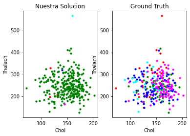

```python
#dibujamos nuestro agrupamiento y la solucion para ver la diferencia
prov=df.iloc[:,[4,7]].values

fig, ax = plt.subplots(1,2)

ax[0].scatter(prov[labels == 1, 1], prov[labels == 1, 0], s = 10, c = 'red', label = 'Cluster 1')
ax[0].scatter(prov[labels == 2, 1], prov[labels == 2, 0], s = 10, c = 'blue', label = 'Cluster 2')
ax[0].scatter(prov[labels == 3, 1], prov[labels == 3, 0], s = 10, c = 'green', label = 'Cluster 3')
ax[0].scatter(prov[labels == 4, 1], prov[labels == 4, 0], s = 10, c = 'cyan', label = 'Cluster 4')
ax[0].scatter(prov[labels == 5, 1], prov[labels == 5, 0], s = 10, c = 'magenta', label = 'Cluster 5')
ax[0].set_title('Nuestra Solucion')
ax[0].set_xlabel('Chol')
ax[0].set_ylabel('Thalach')
#plt.legend()


ax[1].scatter(prov[solution == 1, 1], prov[solution == 1, 0], s = 10, c = 'red', label = 'Cluster 1')
ax[1].scatter(prov[solution == 2, 1], prov[solution == 2, 0], s = 10, c = 'blue', label = 'Cluster 2')
ax[1].scatter(prov[solution == 3, 1], prov[solution == 3, 0], s = 10, c = 'green', label = 'Cluster 3')
ax[1].scatter(prov[solution == 4, 1], prov[solution == 4, 0], s = 10, c = 'cyan', label = 'Cluster 4')
ax[1].scatter(prov[solution == 5, 1], prov[solution == 5, 0], s = 10, c = 'magenta', label = 'Cluster 5')

ax[1].set_title('Ground Truth')
ax[1].set_xlabel('Chol')
ax[1].set_ylabel('Thalach')
#plt.legend()

plt.show()
```

```python
#Veamos el coeficiente de correlación para los dos vectores de etiquetas
#el del ground truth y el de nuestra solucion (entre -1 y +1)
from scipy.stats import pearsonr
pearsonr(labels, sol)
```

```
(0.09935977782783008, 0.08738672207138848)
```

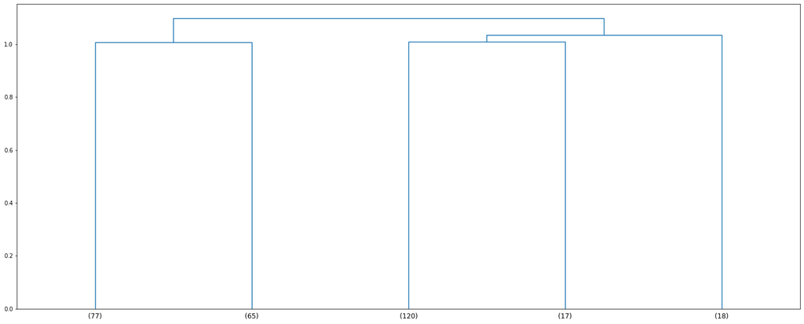

```
[4 3 3 5 2 2 5 3 3 5 4 2 4 2 1 1 5 2 1 2 1 1 2 3 3 1 1 5 2 3 3 3 1 3 1 2 3
 4 3 1 3 3 3 1 3 1 1 3 1 5 2 3 2 2 3 3 1 2 5 3 3 5 3 1 3 3 1 1 5 1 1 3 3 4
 2 1 3 1 2 3 3 3 1 1 2 1 1 3 1 3 5 3 1 1 3 3 3 2 2 2 2 3 1 3 2 3 1 3 3 3 1
 4 3 1 4 1 2 3 3 3 3 1 5 1 2 5 3 2 3 1 1 2 2 1 2 5 2 3 1 2 1 2 1 1 1 3 1 2
 1 1 3 3 3 5 3 3 3 3 1 2 3 1 3 1 3 2 2 2 1 3 3 3 4 3 3 4 1 3 2 3 2 5 3 3 5
 4 2 3 1 3 3 1 3 1 3 2 2 3 3 1 1 2 3 3 3 2 3 1 3 1 3 2 1 2 3 3 2 1 1 1 3 3
 2 2 1 3 3 1 3 3 2 1 3 5 2 2 2 2 2 3 3 1 3 2 3 3 2 4 3 3 1 2 1 3 3 2 2 1 3
 3 1 3 4 4 2 1 3 4 3 3 3 1 1 1 2 3 3 1 3 2 3 3 4 2 5 1 2 4 3 3 2 4 3 3 3 3
 2]
[4, 3, 5, 2, 1]
---
[2 2 2 3 5 5 3 1 4 3 2 5 2 5 3 3 3 2 5 5 2 3 5 2 2 5 5 3 2 2 2 3 5 2 5 2 2
 2 4 3 2 2 5 3 1 4 5 2 3 3 5 2 2 5 2 4 4 2 3 2 1 3 2 3 4 2 3 3 3 3 5 3 2 2
 2 5 4 5 5 2 2 1 5 3 5 5 5 1 5 1 2 2 5 5 2 4 2 5 2 2 2 1 3 2 5 2 4 4 2 1 3
 2 1 5 2 3 2 2 4 3 2 2 3 3 5 3 4 5 1 3 4 5 2 5 5 3 4 2 3 5 3 5 4 3 5 2 5 5
 5 3 1 1 4 3 2 2 2 2 4 5 2 5 1 3 2 5 2 5 4 2 1 1 2 4 2 2 5 2 2 1 2 3 1 5 3
 2 5 2 5 2 2 5 1 3 1 5 3 1 1 3 5 2 2 2 2 5 1 5 2 3 3 2 3 5 1 2 2 5 5 5 2 2
 5 2 5 2 2 5 1 2 5 5 2 3 2 5 5 5 5 1 2 5 1 2 2 2 5 2 4 4 5 2 5 2 1 3 5 5 5
 5 5 2 2 2 2 5 2 2 2 1 2 3 5 5 5 1 4 5 1 5 2 1 2 5 3 3 5 2 2 1 5 2 1 2 3 4
 5]
```

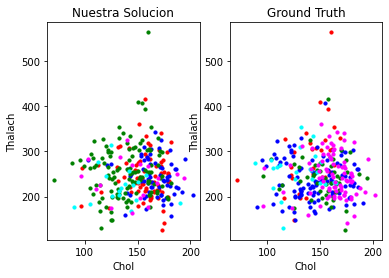

```
(-0.5099736871059833, 4.575015536702144e-21)
```

```python
# Average - Cosine

Z = linkage(heart_scale, method='average', metric='cosine', optimal_ordering=True)
fig = plt.figure(figsize=(25, 10))

dn = dendrogram(Z, p=5, truncate_mode='lastp')
plt.show()

distan = 1
labels = fcluster(Z, t = distan, criterion = 'distance')

print(labels)
print(list(Counter(labels)))
print("---")
sol = np.array(solution)

print(sol)

prov=df.iloc[:,[4,7]].values

fig, ax = plt.subplots(1,2)

ax[0].scatter(prov[labels == 1, 1], prov[labels == 1, 0], s = 10, c = 'red', label = 'Cluster 1')
ax[0].scatter(prov[labels == 2, 1], prov[labels == 2, 0], s = 10, c = 'blue', label = 'Cluster 2')
ax[0].scatter(prov[labels == 3, 1], prov[labels == 3, 0], s = 10, c = 'green', label = 'Cluster 3')
ax[0].scatter(prov[labels == 4, 1], prov[labels == 4, 0], s = 10, c = 'cyan', label = 'Cluster 4')
ax[0].scatter(prov[labels == 5, 1], prov[labels == 5, 0], s = 10, c = 'magenta', label = 'Cluster 5')
ax[0].set_title('Nuestra Solucion')
ax[0].set_xlabel('Chol')
ax[0].set_ylabel('Thalach')
#plt.legend()


ax[1].scatter(prov[solution == 1, 1], prov[solution == 1, 0], s = 10, c = 'red', label = 'Cluster 1')
ax[1].scatter(prov[solution == 2, 1], prov[solution == 2, 0], s = 10, c = 'blue', label = 'Cluster 2')
ax[1].scatter(prov[solution == 3, 1], prov[solution == 3, 0], s = 10, c = 'green', label = 'Cluster 3')
ax[1].scatter(prov[solution == 4, 1], prov[solution == 4, 0], s = 10, c = 'cyan', label = 'Cluster 4')
ax[1].scatter(prov[solution == 5, 1], prov[solution == 5, 0], s = 10, c = 'magenta', label = 'Cluster 5')

ax[1].set_title('Ground Truth')
ax[1].set_xlabel('Chol')
ax[1].set_ylabel('Thalach')

plt.show()

pearsonr(labels, sol)
```

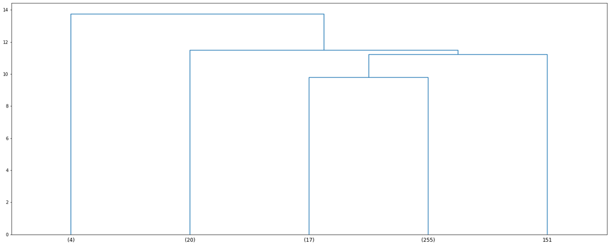

```
[2 3 4 2 4 4 2 4 4 2 4 4 4 4 4 4 2 4 4 4 4 4 4 4 4 4 4 2 4 4 4 4 4 4 4 4 4
 4 4 4 3 4 4 4 4 4 4 4 4 2 4 4 4 4 4 4 4 4 2 4 4 2 3 4 4 4 4 4 2 4 4 4 4 4
 4 4 4 4 4 4 4 4 4 4 4 4 4 4 4 4 2 3 4 4 4 4 4 4 4 4 4 4 4 3 4 4 4 4 4 4 4
 4 4 4 4 4 4 3 4 4 3 4 2 4 4 2 4 4 4 4 4 4 4 4 4 2 4 4 4 4 4 4 4 4 4 3 4 4
 4 4 4 5 4 2 3 4 4 4 4 4 3 4 4 4 4 4 4 4 4 4 4 4 4 4 3 4 4 3 4 4 4 2 4 4 2
 4 4 3 4 3 3 4 4 4 4 4 4 4 4 4 4 4 3 4 4 4 4 4 4 4 4 4 4 4 4 4 4 4 4 4 4 4
 4 4 4 4 4 4 1 3 4 4 4 2 4 4 4 4 4 4 4 4 4 4 4 4 4 4 4 4 4 4 4 4 1 4 4 4 4
 4 4 4 4 4 4 4 4 4 4 4 4 4 4 4 4 4 4 4 1 4 4 1 4 4 2 4 4 2 4 4 4 4 4 4 4 4
 4]
[2, 3, 4, 5, 1]
---
[2 2 2 3 5 5 3 1 4 3 2 5 2 5 3 3 3 2 5 5 2 3 5 2 2 5 5 3 2 2 2 3 5 2 5 2 2
 2 4 3 2 2 5 3 1 4 5 2 3 3 5 2 2 5 2 4 4 2 3 2 1 3 2 3 4 2 3 3 3 3 5 3 2 2
 2 5 4 5 5 2 2 1 5 3 5 5 5 1 5 1 2 2 5 5 2 4 2 5 2 2 2 1 3 2 5 2 4 4 2 1 3
 2 1 5 2 3 2 2 4 3 2 2 3 3 5 3 4 5 1 3 4 5 2 5 5 3 4 2 3 5 3 5 4 3 5 2 5 5
 5 3 1 1 4 3 2 2 2 2 4 5 2 5 1 3 2 5 2 5 4 2 1 1 2 4 2 2 5 2 2 1 2 3 1 5 3
 2 5 2 5 2 2 5 1 3 1 5 3 1 1 3 5 2 2 2 2 5 1 5 2 3 3 2 3 5 1 2 2 5 5 5 2 2
 5 2 5 2 2 5 1 2 5 5 2 3 2 5 5 5 5 1 2 5 1 2 2 2 5 2 4 4 5 2 5 2 1 3 5 5 5
 5 5 2 2 2 2 5 2 2 2 1 2 3 5 5 5 1 4 5 1 5 2 1 2 5 3 3 5 2 2 1 5 2 1 2 3 4
 5]
```

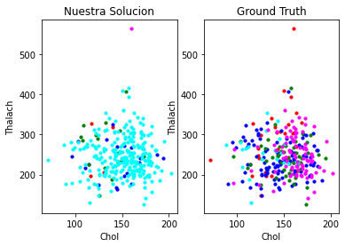

```
(0.1879636586050366, 0.0011351031015401254)
```

```python
# Complete - Euclidean

Z = linkage(heart_scale, method='complete', metric='euclidean', optimal_ordering=True)
fig = plt.figure(figsize=(25, 10))

dn = dendrogram(Z, p=5, truncate_mode='lastp')
plt.show()

distan = 9.75
labels = fcluster(Z, t = distan, criterion = 'distance')

print(labels)
print(list(Counter(labels)))
print("---")
sol = np.array(solution)

print(sol)

prov=df.iloc[:,[4,7]].values

fig, ax = plt.subplots(1,2)

ax[0].scatter(prov[labels == 1, 1], prov[labels == 1, 0], s = 10, c = 'red', label = 'Cluster 1')
ax[0].scatter(prov[labels == 2, 1], prov[labels == 2, 0], s = 10, c = 'blue', label = 'Cluster 2')
ax[0].scatter(prov[labels == 3, 1], prov[labels == 3, 0], s = 10, c = 'green', label = 'Cluster 3')
ax[0].scatter(prov[labels == 4, 1], prov[labels == 4, 0], s = 10, c = 'cyan', label = 'Cluster 4')
ax[0].scatter(prov[labels == 5, 1], prov[labels == 5, 0], s = 10, c = 'magenta', label = 'Cluster 5')
ax[0].set_title('Nuestra Solucion')
ax[0].set_xlabel('Chol')
ax[0].set_ylabel('Thalach')
#plt.legend()


ax[1].scatter(prov[solution == 1, 1], prov[solution == 1, 0], s = 10, c = 'red', label = 'Cluster 1')
ax[1].scatter(prov[solution == 2, 1], prov[solution == 2, 0], s = 10, c = 'blue', label = 'Cluster 2')
ax[1].scatter(prov[solution == 3, 1], prov[solution == 3, 0], s = 10, c = 'green', label = 'Cluster 3')
ax[1].scatter(prov[solution == 4, 1], prov[solution == 4, 0], s = 10, c = 'cyan', label = 'Cluster 4')
ax[1].scatter(prov[solution == 5, 1], prov[solution == 5, 0], s = 10, c = 'magenta', label = 'Cluster 5')

ax[1].set_title('Ground Truth')
ax[1].set_xlabel('Chol')
ax[1].set_ylabel('Thalach')

plt.show()

pearsonr(labels, sol)
```

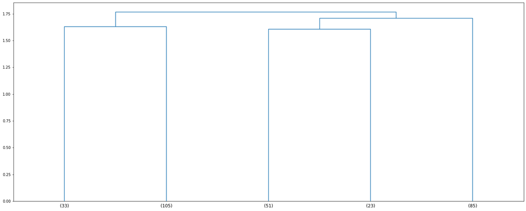

```
[2 2 2 3 5 5 3 1 4 3 2 5 2 5 3 3 3 2 5 5 2 3 5 2 2 5 5 3 2 2 2 3 5 2 5 2 2
 2 4 3 2 2 5 3 1 4 5 2 3 3 5 2 2 5 2 4 4 2 3 2 1 3 2 3 4 2 3 3 3 3 5 3 2 2
 2 5 4 5 5 2 2 1 5 3 5 5 5 1 5 1 2 2 5 5 2 4 2 5 2 2 2 1 3 2 5 2 4 4 2 1 3
 2 1 5 2 3 2 2 4 3 2 2 3 3 5 3 4 5 1 3 4 5 2 5 5 3 4 2 3 5 3 5 4 3 5 2 5 5
 5 3 1 1 4 3 2 2 2 2 4 5 2 5 1 3 2 5 2 5 4 2 1 1 2 4 2 2 5 2 2 1 2 3 1 5 3
 2 5 2 5 2 2 5 1 3 1 5 3 1 1 3 5 2 2 2 2 5 1 5 2 3 3 2 3 5 1 2 2 5 5 5 2 2
 5 2 5 2 2 5 1 2 5 5 2 3 2 5 5 5 5 1 2 5 1 2 2 2 5 2 4 4 5 2 5 2 1 3 5 5 5
 5 5 2 2 2 2 5 2 2 2 1 2 3 5 5 5 1 4 5 1 5 2 1 2 5 3 3 5 2 2 1 5 2 1 2 3 4
 5]
[2, 3, 5, 1, 4]
---
[2 2 2 3 5 5 3 1 4 3 2 5 2 5 3 3 3 2 5 5 2 3 5 2 2 5 5 3 2 2 2 3 5 2 5 2 2
 2 4 3 2 2 5 3 1 4 5 2 3 3 5 2 2 5 2 4 4 2 3 2 1 3 2 3 4 2 3 3 3 3 5 3 2 2
 2 5 4 5 5 2 2 1 5 3 5 5 5 1 5 1 2 2 5 5 2 4 2 5 2 2 2 1 3 2 5 2 4 4 2 1 3
 2 1 5 2 3 2 2 4 3 2 2 3 3 5 3 4 5 1 3 4 5 2 5 5 3 4 2 3 5 3 5 4 3 5 2 5 5
 5 3 1 1 4 3 2 2 2 2 4 5 2 5 1 3 2 5 2 5 4 2 1 1 2 4 2 2 5 2 2 1 2 3 1 5 3
 2 5 2 5 2 2 5 1 3 1 5 3 1 1 3 5 2 2 2 2 5 1 5 2 3 3 2 3 5 1 2 2 5 5 5 2 2
 5 2 5 2 2 5 1 2 5 5 2 3 2 5 5 5 5 1 2 5 1 2 2 2 5 2 4 4 5 2 5 2 1 3 5 5 5
 5 5 2 2 2 2 5 2 2 2 1 2 3 5 5 5 1 4 5 1 5 2 1 2 5 3 3 5 2 2 1 5 2 1 2 3 4
 5]
```

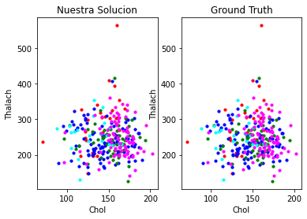

```
(1.0, 0.0)
```

```python
# Complete - Cosine

Z = linkage(heart_scale, method='complete', metric='cosine', optimal_ordering=True)
fig = plt.figure(figsize=(25, 10))

dn = dendrogram(Z, p=5, truncate_mode='lastp')
plt.show()

distan = 1.6
labels = fcluster(Z, t = distan, criterion = 'distance')

print(labels)
print(list(Counter(labels)))
print("---")
sol = np.array(solution)

print(sol)

prov=df.iloc[:,[4,7]].values

fig, ax = plt.subplots(1,2)

ax[0].scatter(prov[labels == 1, 1], prov[labels == 1, 0], s = 10, c = 'red', label = 'Cluster 1')
ax[0].scatter(prov[labels == 2, 1], prov[labels == 2, 0], s = 10, c = 'blue', label = 'Cluster 2')
ax[0].scatter(prov[labels == 3, 1], prov[labels == 3, 0], s = 10, c = 'green', label = 'Cluster 3')
ax[0].scatter(prov[labels == 4, 1], prov[labels == 4, 0], s = 10, c = 'cyan', label = 'Cluster 4')
ax[0].scatter(prov[labels == 5, 1], prov[labels == 5, 0], s = 10, c = 'magenta', label = 'Cluster 5')
ax[0].set_title('Nuestra Solucion')
ax[0].set_xlabel('Chol')
ax[0].set_ylabel('Thalach')
#plt.legend()


ax[1].scatter(prov[solution == 1, 1], prov[solution == 1, 0], s = 10, c = 'red', label = 'Cluster 1')
ax[1].scatter(prov[solution == 2, 1], prov[solution == 2, 0], s = 10, c = 'blue', label = 'Cluster 2')
ax[1].scatter(prov[solution == 3, 1], prov[solution == 3, 0], s = 10, c = 'green', label = 'Cluster 3')
ax[1].scatter(prov[solution == 4, 1], prov[solution == 4, 0], s = 10, c = 'cyan', label = 'Cluster 4')
ax[1].scatter(prov[solution == 5, 1], prov[solution == 5, 0], s = 10, c = 'magenta', label = 'Cluster 5')

ax[1].set_title('Ground Truth')
ax[1].set_xlabel('Chol')
ax[1].set_ylabel('Thalach')

plt.show()

pearsonr(labels, sol)
```

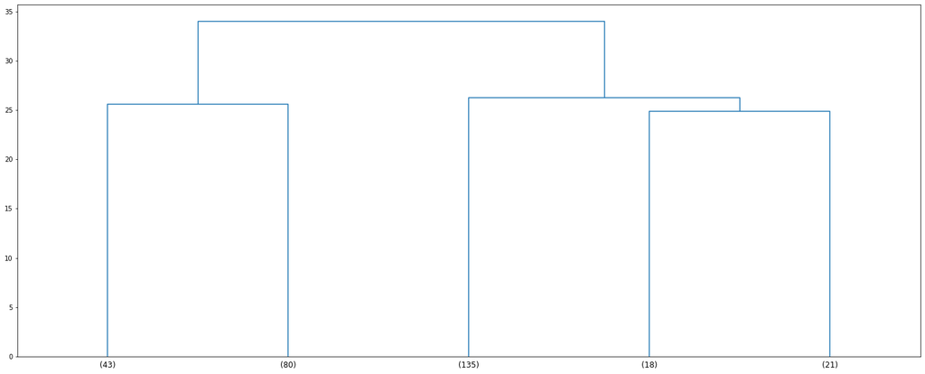

```
[5 3 3 4 1 1 4 3 3 4 5 1 5 1 2 2 4 3 2 1 2 2 1 3 3 2 2 4 3 3 3 3 2 3 2 3 3
 5 3 2 3 3 1 2 3 2 2 3 2 4 1 3 3 1 3 3 2 3 4 3 3 4 3 2 3 3 2 2 4 2 2 3 3 5
 3 2 3 2 1 3 3 3 2 2 1 2 2 3 2 3 4 3 2 2 3 3 3 1 3 3 2 3 2 3 1 3 2 3 3 3 3
 5 3 2 5 2 3 3 3 3 3 2 4 2 1 4 3 1 3 2 2 1 3 2 1 4 3 3 2 1 2 1 2 2 2 3 2 1
 2 2 3 2 3 4 3 3 3 3 2 1 3 2 3 2 3 1 3 1 2 3 3 3 5 3 3 5 2 3 3 3 2 4 3 1 4
 5 1 3 2 3 3 2 3 2 3 1 2 3 3 2 2 3 3 3 3 1 3 2 3 2 3 3 3 1 3 3 3 2 2 2 3 3
 1 3 2 3 3 2 5 3 1 2 3 4 3 1 1 1 1 3 3 2 3 3 3 3 1 5 3 3 2 3 2 3 5 2 1 2 1
 3 2 3 5 5 3 2 3 5 3 3 3 2 2 2 1 3 3 2 5 1 3 5 5 1 4 2 1 5 3 3 1 5 3 3 3 3
 1]
[5, 3, 4, 1, 2]
---
[2 2 2 3 5 5 3 1 4 3 2 5 2 5 3 3 3 2 5 5 2 3 5 2 2 5 5 3 2 2 2 3 5 2 5 2 2
 2 4 3 2 2 5 3 1 4 5 2 3 3 5 2 2 5 2 4 4 2 3 2 1 3 2 3 4 2 3 3 3 3 5 3 2 2
 2 5 4 5 5 2 2 1 5 3 5 5 5 1 5 1 2 2 5 5 2 4 2 5 2 2 2 1 3 2 5 2 4 4 2 1 3
 2 1 5 2 3 2 2 4 3 2 2 3 3 5 3 4 5 1 3 4 5 2 5 5 3 4 2 3 5 3 5 4 3 5 2 5 5
 5 3 1 1 4 3 2 2 2 2 4 5 2 5 1 3 2 5 2 5 4 2 1 1 2 4 2 2 5 2 2 1 2 3 1 5 3
 2 5 2 5 2 2 5 1 3 1 5 3 1 1 3 5 2 2 2 2 5 1 5 2 3 3 2 3 5 1 2 2 5 5 5 2 2
 5 2 5 2 2 5 1 2 5 5 2 3 2 5 5 5 5 1 2 5 1 2 2 2 5 2 4 4 5 2 5 2 1 3 5 5 5
 5 5 2 2 2 2 5 2 2 2 1 2 3 5 5 5 1 4 5 1 5 2 1 2 5 3 3 5 2 2 1 5 2 1 2 3 4
 5]
```

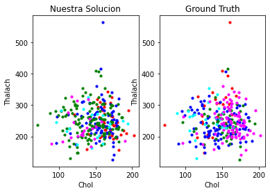

```
(-0.6854690958462604, 1.498634978684503e-42)
```

```python
# Ward - Euclidean

Z = linkage(heart_scale, method='ward', metric='euclidean', optimal_ordering=True)
fig = plt.figure(figsize=(25, 10))

dn = dendrogram(Z, p=5, truncate_mode='lastp')
plt.show()

distan = 24.8
labels = fcluster(Z, t = distan, criterion = 'distance')

print(labels)
print(list(Counter(labels)))
print("---")
sol = np.array(solution)

print(sol)

prov=df.iloc[:,[4,7]].values

fig, ax = plt.subplots(1,2)

ax[0].scatter(prov[labels == 1, 1], prov[labels == 1, 0], s = 10, c = 'red', label = 'Cluster 1')
ax[0].scatter(prov[labels == 2, 1], prov[labels == 2, 0], s = 10, c = 'blue', label = 'Cluster 2')
ax[0].scatter(prov[labels == 3, 1], prov[labels == 3, 0], s = 10, c = 'green', label = 'Cluster 3')
ax[0].scatter(prov[labels == 4, 1], prov[labels == 4, 0], s = 10, c = 'cyan', label = 'Cluster 4')
ax[0].scatter(prov[labels == 5, 1], prov[labels == 5, 0], s = 10, c = 'magenta', label = 'Cluster 5')
ax[0].set_title('Nuestra Solucion')
ax[0].set_xlabel('Chol')
ax[0].set_ylabel('Thalach')
#plt.legend()


ax[1].scatter(prov[solution == 1, 1], prov[solution == 1, 0], s = 10, c = 'red', label = 'Cluster 1')
ax[1].scatter(prov[solution == 2, 1], prov[solution == 2, 0], s = 10, c = 'blue', label = 'Cluster 2')
ax[1].scatter(prov[solution == 3, 1], prov[solution == 3, 0], s = 10, c = 'green', label = 'Cluster 3')
ax[1].scatter(prov[solution == 4, 1], prov[solution == 4, 0], s = 10, c = 'cyan', label = 'Cluster 4')
ax[1].scatter(prov[solution == 5, 1], prov[solution == 5, 0], s = 10, c = 'magenta', label = 'Cluster 5')

ax[1].set_title('Ground Truth')
ax[1].set_xlabel('Chol')
ax[1].set_ylabel('Thalach')

plt.show()

pearsonr(labels, sol)
```

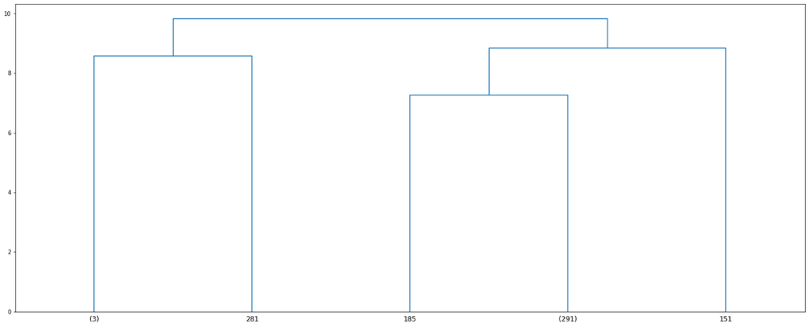

```
[3 3 3 3 3 3 3 3 3 3 3 3 3 3 3 3 3 3 3 3 3 3 3 3 3 3 3 3 3 3 3 3 3 3 3 3 3
 3 3 3 3 3 3 3 3 3 3 3 3 3 3 3 3 3 3 3 3 3 3 3 3 3 3 3 3 3 3 3 3 3 3 3 3 3
 3 3 3 3 3 3 3 3 3 3 3 3 3 3 3 3 3 3 3 3 3 3 3 3 3 3 3 3 3 3 3 3 3 3 3 3 3
 3 3 3 3 3 3 3 3 3 3 3 3 3 3 3 3 3 3 3 3 3 3 3 3 3 3 3 3 3 3 3 3 3 3 3 3 3
 3 3 3 6 3 3 3 3 3 3 3 3 3 3 3 3 3 3 3 3 3 3 3 3 3 3 3 3 3 3 3 3 3 3 3 3 3
 5 4 3 3 3 3 3 3 3 3 3 3 3 3 3 3 3 3 3 3 3 3 3 3 3 3 3 3 3 3 3 3 3 3 3 3 3
 3 3 3 3 3 3 1 3 3 3 3 3 3 3 3 3 3 3 3 3 3 3 3 3 3 3 3 3 3 3 3 3 1 3 3 3 3
 3 3 3 3 3 3 3 3 3 3 3 3 3 3 3 3 3 3 3 1 3 3 2 3 3 3 3 3 3 3 3 3 3 3 3 3 3
 3]
[3, 6, 5, 4, 1, 2]
---
[2 2 2 3 5 5 3 1 4 3 2 5 2 5 3 3 3 2 5 5 2 3 5 2 2 5 5 3 2 2 2 3 5 2 5 2 2
 2 4 3 2 2 5 3 1 4 5 2 3 3 5 2 2 5 2 4 4 2 3 2 1 3 2 3 4 2 3 3 3 3 5 3 2 2
 2 5 4 5 5 2 2 1 5 3 5 5 5 1 5 1 2 2 5 5 2 4 2 5 2 2 2 1 3 2 5 2 4 4 2 1 3
 2 1 5 2 3 2 2 4 3 2 2 3 3 5 3 4 5 1 3 4 5 2 5 5 3 4 2 3 5 3 5 4 3 5 2 5 5
 5 3 1 1 4 3 2 2 2 2 4 5 2 5 1 3 2 5 2 5 4 2 1 1 2 4 2 2 5 2 2 1 2 3 1 5 3
 2 5 2 5 2 2 5 1 3 1 5 3 1 1 3 5 2 2 2 2 5 1 5 2 3 3 2 3 5 1 2 2 5 5 5 2 2
 5 2 5 2 2 5 1 2 5 5 2 3 2 5 5 5 5 1 2 5 1 2 2 2 5 2 4 4 5 2 5 2 1 3 5 5 5
 5 5 2 2 2 2 5 2 2 2 1 2 3 5 5 5 1 4 5 1 5 2 1 2 5 3 3 5 2 2 1 5 2 1 2 3 4
 5]
```

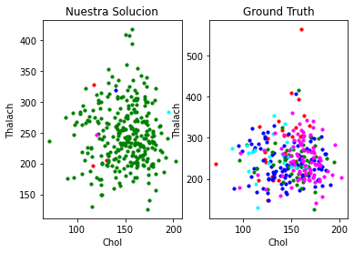

```
(0.06352620152456623, 0.2751511602974481)
```

```python
# Median - Euclidean

Z = linkage(heart_scale, method='median', metric='euclidean', optimal_ordering=True)
fig = plt.figure(figsize=(25, 10))

dn = dendrogram(Z, p=5, truncate_mode='lastp')
plt.show()

distan = 7.9487776179251 #X
labels = fcluster(Z, t = distan, criterion = 'distance')

print(labels)
print(list(Counter(labels)))
print("---")
sol = np.array(solution)

print(sol)

prov=df.iloc[:,[4,7]].values

fig, ax = plt.subplots(1,2)

ax[0].scatter(prov[labels == 1, 1], prov[labels == 1, 0], s = 10, c = 'red', label = 'Cluster 1')
ax[0].scatter(prov[labels == 2, 1], prov[labels == 2, 0], s = 10, c = 'blue', label = 'Cluster 2')
ax[0].scatter(prov[labels == 3, 1], prov[labels == 3, 0], s = 10, c = 'green', label = 'Cluster 3')
ax[0].scatter(prov[labels == 4, 1], prov[labels == 4, 0], s = 10, c = 'cyan', label = 'Cluster 4')
ax[0].scatter(prov[labels == 5, 1], prov[labels == 5, 0], s = 10, c = 'magenta', label = 'Cluster 5')
ax[0].set_title('Nuestra Solucion')
ax[0].set_xlabel('Chol')
ax[0].set_ylabel('Thalach')
#plt.legend()


ax[1].scatter(prov[solution == 1, 1], prov[solution == 1, 0], s = 10, c = 'red', label = 'Cluster 1')
ax[1].scatter(prov[solution == 2, 1], prov[solution == 2, 0], s = 10, c = 'blue', label = 'Cluster 2')
ax[1].scatter(prov[solution == 3, 1], prov[solution == 3, 0], s = 10, c = 'green', label = 'Cluster 3')
ax[1].scatter(prov[solution == 4, 1], prov[solution == 4, 0], s = 10, c = 'cyan', label = 'Cluster 4')
ax[1].scatter(prov[solution == 5, 1], prov[solution == 5, 0], s = 10, c = 'magenta', label = 'Cluster 5')

ax[1].set_title('Ground Truth')
ax[1].set_xlabel('Chol')
ax[1].set_ylabel('Thalach')

plt.show()

pearsonr(labels, sol)
```

### Recuerda hacer este paso 2 con todos los linkages y métricas

**ACTVIDAD 3** Escribe aquí una crítica (lo más técnica posible) a los resultados que has obtenido con todas las combinaciones Indica si en algún dendrograma se producen crossovers

### Paso 3 Comprobar sensibilidad al ruido

Como sabes, el agrupamiento jerarquico es muy sensible al ruido. Basta que unas pocas muestras sean algo diferentes en valores (debido al ruido del proceso de sensorización por ejemplo) para que el agrupamiento cambie considerablemente

Para comprobarlo, crea un nuevo dataset **'data_patients_noisy.csv'** editando el original y cambiando los valores de las características de solo 10 datos (10 filas).Pon valores claramente distintos a los originales,aunque dentro del rango valido de los mismos)

Vuelve a hacer con este dataset el preprocesamiento y el agrupamiento jerárquico **con la combinación de linkage y métrica que mejor te haya funcionado en el Paso 2** (Solo una combinacion) .Visualiza los datos Compara también los dos vectores de etiquetas calculando su coef de correlacion.

**ACTIVIDAD 4**Compara los resultados que has obtenido con los del Paso 2

```python
df2 = pd.read_csv("./data_patients_noisy.csv")
df2.dropna(inplace = True)
solution2 = df2['Target']
df2=df2.drop(columns=['Target'])
df_dum2 = pd.get_dummies(data = df2, columns = ["Sex","Cp","Fbs","Restecg","Exang","Slope","Ca","Thal"], drop_first = True).astype(int)
heart_scale2 = df_dum2
scaler2 = preprocessing.StandardScaler()
columns2 =df_dum2.columns
heart_scale2[columns2] = scaler2.fit_transform(heart_scale2[columns2])
```

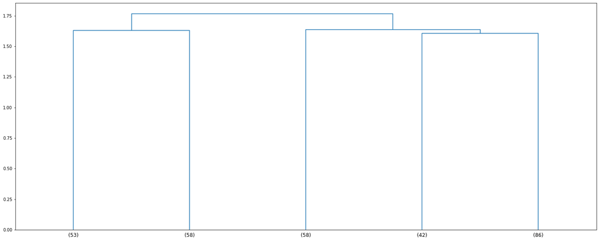

```
[5 5 2 5 4 4 5 1 2 5 5 4 5 4 5 3 5 1 3 4 2 5 4 5 2 3 3 5 1 2 5 5 3 2 3 1 2
 5 2 5 5 2 5 5 1 3 3 2 5 5 4 2 2 4 2 2 3 1 5 2 1 5 5 5 2 2 3 3 5 3 3 5 2 5
 2 3 2 3 4 2 2 1 3 5 4 3 3 1 3 1 5 5 3 3 2 2 2 4 1 1 1 1 5 5 4 2 3 2 2 1 5
 5 1 3 5 5 1 5 2 5 5 2 5 5 4 5 2 4 1 3 3 4 1 3 4 5 4 2 5 4 1 4 3 3 3 5 3 4
 3 5 1 1 2 5 5 2 5 5 3 4 5 3 1 5 2 4 1 4 3 2 1 1 5 2 5 5 3 5 1 1 1 5 1 5 5
 5 4 5 3 5 5 3 2 5 1 4 1 1 1 5 3 1 5 2 2 4 1 3 2 3 5 2 3 4 1 5 1 3 3 3 2 5
 4 1 3 2 2 3 1 5 4 3 2 5 1 4 4 4 4 1 5 3 1 2 2 5 4 5 2 2 3 1 3 5 1 4 4 3 5
 3 3 2 5 5 1 3 2 5 2 1 5 1 3 3 4 1 2 3 1 4 2 1 5 4 5 3 4 5 2 1 4 5 1 2 5 2
 4]
[5, 2, 4, 1, 3]
---
[2 2 2 3 5 5 3 1 4 3 2 5 2 5 3 3 3 2 5 5 2 3 5 2 2 5 5 3 2 2 2 3 5 2 5 2 2
 2 4 3 2 2 5 3 1 4 5 2 3 3 5 2 2 5 2 4 4 2 3 2 1 3 2 3 4 2 3 3 3 3 5 3 2 2
 2 5 4 5 5 2 2 1 5 3 5 5 5 1 5 1 2 2 5 5 2 4 2 5 2 2 2 1 3 2 5 2 4 4 2 1 3
 2 1 5 2 3 2 2 4 3 2 2 3 3 5 3 4 5 1 3 4 5 2 5 5 3 4 2 3 5 3 5 4 3 5 2 5 5
 5 3 1 1 4 3 2 2 2 2 4 5 2 5 1 3 2 5 2 5 4 2 1 1 2 4 2 2 5 2 2 1 2 3 1 5 3
 2 5 2 5 2 2 5 1 3 1 5 3 1 1 3 5 2 2 2 2 5 1 5 2 3 3 2 3 5 1 2 2 5 5 5 2 2
 5 2 5 2 2 5 1 2 5 5 2 3 2 5 5 5 5 1 2 5 1 2 2 2 5 2 4 4 5 2 5 2 1 3 5 5 5
 5 5 2 2 2 2 5 2 2 2 1 2 3 5 5 5 1 4 5 1 5 2 1 2 5 3 3 5 2 2 1 5 2 1 2 3 4
 5]
```

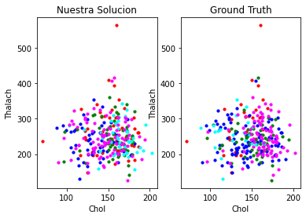

```
(0.3089145258402894, 5.486161827132649e-08)
```

```python
# Complete - Cosine

Z = linkage(heart_scale2, method='complete', metric='cosine', optimal_ordering=True)
fig = plt.figure(figsize=(25, 10))

dn = dendrogram(Z, p=5, truncate_mode='lastp')
plt.show()

distan = 1.6
labels = fcluster(Z, t = distan, criterion = 'distance')

print(labels)
print(list(Counter(labels)))
print("---")
sol = np.array(solution)

print(sol)

prov=df.iloc[:,[4,7]].values

fig, ax = plt.subplots(1,2)

ax[0].scatter(prov[labels == 1, 1], prov[labels == 1, 0], s = 10, c = 'red', label = 'Cluster 1')
ax[0].scatter(prov[labels == 2, 1], prov[labels == 2, 0], s = 10, c = 'blue', label = 'Cluster 2')
ax[0].scatter(prov[labels == 3, 1], prov[labels == 3, 0], s = 10, c = 'green', label = 'Cluster 3')
ax[0].scatter(prov[labels == 4, 1], prov[labels == 4, 0], s = 10, c = 'cyan', label = 'Cluster 4')
ax[0].scatter(prov[labels == 5, 1], prov[labels == 5, 0], s = 10, c = 'magenta', label = 'Cluster 5')
ax[0].set_title('Nuestra Solucion')
ax[0].set_xlabel('Chol')
ax[0].set_ylabel('Thalach')
#plt.legend()


ax[1].scatter(prov[solution == 1, 1], prov[solution == 1, 0], s = 10, c = 'red', label = 'Cluster 1')
ax[1].scatter(prov[solution == 2, 1], prov[solution == 2, 0], s = 10, c = 'blue', label = 'Cluster 2')
ax[1].scatter(prov[solution == 3, 1], prov[solution == 3, 0], s = 10, c = 'green', label = 'Cluster 3')
ax[1].scatter(prov[solution == 4, 1], prov[solution == 4, 0], s = 10, c = 'cyan', label = 'Cluster 4')
ax[1].scatter(prov[solution == 5, 1], prov[solution == 5, 0], s = 10, c = 'magenta', label = 'Cluster 5')

ax[1].set_title('Ground Truth')
ax[1].set_xlabel('Chol')
ax[1].set_ylabel('Thalach')

plt.show()

pearsonr(labels, sol)
```

Hemos podido comprobar que al cambiar una característica para 10 observaciones de nuestros datos, el coeficiente de pearsson cambia de 1 a 0.31, esto sugiere que al usar el agrupamiento aglomerativo debemos tener cuidado con los datos extraños o outliers ya que pueden perjudicar a nuestro modelo.